# 通过tensorflow serving在生产系统部署模型

通过tensorflow编写、训练和测试模型，咱们都已经轻车熟路，但是在生产环境部署模型挺不容易。在tensorflow中默认有两种方法[TensorFlow 模型保存/载入](https://blog.csdn.net/thriving_fcl/article/details/71423039)保存参数，使用Saver方法仅保存变量在推断的时候需要重新定义Graph,使用tf.train.import_meta_graph导入graph信息并创建Saver，再使用Saver restore变量，但是为了找到输入输出的tensor，还得用graph.get_tensor_by_name()来获取，也就是还需要知道在定义模型阶段所赋予这些tensor的名字。

谷歌提供的模型部署组件[tensorflow serving](https://tensorflow.google.cn/serving/),解决了上面的问题。不过目前官网提供的二进制安装包不支持GPU，需要支持GPU的需要重源码编译，请参考下面的链接。

本文通过tensorflow serving部署一组预测模型的完成过程，记录各个接口的编码过程

[saved_model模块](http://blog.csdn.net/thriving_fcl/article/details/75213361)

[Introductory Tutorial to TensorFlow Serving](https://weiminwang.blog/2017/09/12/introductory-guide-to-tensorflow-serving/)

[Tensorflow Serving | model server GPU版本编译](https://sczhengyabin.me/2017/12/05/Tesorflow-Serving-GPU/)

[Improve TensorFlow Serving Performance With GPU Support](https://docs.bitnami.com/google/how-to/enable-nvidia-gpu-tensorflow-serving/)

[为什么tensorflow serving没有占用GPU](https://zhuanlan.zhihu.com/p/30634248)

[How to Deploy a Tensorflow Model in Production](https://github.com/llSourcell/How-to-Deploy-a-Tensorflow-Model-in-Production/blob/master/demo.ipynb)

### 1）安装tensorflow serving

安装tensorflow serving的方法有两种，一种是通过二进制包安装，简单快捷；一种是通过源码安装，编译过程经常出错，不过需要GPU支持的话，需要从源码编译。具体请参考[tensorflow serving install](https://tensorflow.google.cn/serving/setup)

### 2）编写支持tensorflow serving的模型

也就是接口变量需要通过tf.saved_model模块来保存

```python
import tensorflow as tf
import numpy as np
import matplotlib.pyplot as plt
import os
tf.reset_default_graph()
```

```python
dataset = np.loadtxt('/home/zzx/2.txt')
dataset[:10]
```

```
array([  618.,   454.,   391.,   390.,   378.,   395.,   441.,   624.,
        1131.,  1565.])
```

```python
dataset = (dataset - dataset.mean())/dataset.std()
dataset[:10]
```

```
array([-0.23577144, -0.41557363, -0.48464398, -0.48574034, -0.49889659,
       -0.48025856, -0.42982624, -0.22919331,  0.32665857,  0.80247656])
```

```python
#设置模型输出的路径
MODELS_OUPUT_DIR='/home/zzx/scenic_prediction/models2'
VERSION='01'

#模型参数
window_size=20
rnn_size=20
batch_size=100
LEARNING_RATE=0.001
NUM_EPOCHS=15
```

数据预处理

```python
#序列数据的截取函数
def window_transform_series(series,window_size):
    X = [series[i:(i+window_size)] for i in range(len(series)-window_size)]
    y = [series[i+window_size] for i in range(len(series)-window_size)]
    # reshape each
    X = np.asarray(X)
    X.shape = (np.shape(X)[0:2])
    y = np.asarray(y)
    y.shape = (len(y),1)

    return X,y

#获取输入输出数据
X,y = window_transform_series(series = dataset,window_size = window_size)

#分析训练集和测试集
train_test_split = int(np.ceil(9*len(y)/float(10)))
X_train = X[:train_test_split,:]
y_train = y[:train_test_split]
X_test = X[train_test_split:,:]
y_test = y[train_test_split:]

X_train = np.asarray(np.reshape(X_train, (X_train.shape[0], window_size, 1)))
X_test = np.asarray(np.reshape(X_test, (X_test.shape[0], window_size, 1)))

print(X_train.shape)
print(y_train.shape)



def get_batches(batch_size,x_inputs,y_outputs):
    batches_len=int(np.floor(len(x_inputs)/batch_size))
    print(batches_len)
    x_batches=np.asarray([x_inputs[i*batch_size:(i+1)*batch_size,:] for i in range(0,batches_len)]).astype(np.float64)
    y_batches=np.asarray([y_outputs[i*batch_size:(i+1)*batch_size,:] for i in range(0,batches_len)]).astype(np.float64)
    return x_batches,y_batches
```

```
(6637, 20, 1)
(6637, 1)
```

模型定义

```python
inputs = tf.placeholder(tf.float32, [None, None,1],name='inputs')
targets = tf.placeholder(tf.float32, [None, None],name='targets')
lr = tf.placeholder(tf.float32, name='lr')

def model(inputs,rnn_size,batch_size):
    num_layers=1
    lstm = tf.contrib.rnn.BasicLSTMCell(rnn_size,state_is_tuple=False,activation=tf.nn.relu)
    cell = tf.contrib.rnn.MultiRNNCell([lstm] * num_layers)
    inital_state=tf.identity(cell.zero_state(batch_size,tf.float32),name='initial_state')
    outputs,final_state=tf.nn.dynamic_rnn(cell=cell,inputs=inputs,dtype=tf.float32)
    print(final_state)
    #最后的链接层不再需要激活函数
    logits=tf.contrib.layers.fully_connected(inputs=outputs[:, -1],num_outputs=1,activation_fn=None)
    return logits,inital_state


logits,inital_state = model(inputs,rnn_size,batch_size)
cost = tf.losses.mean_squared_error(labels=targets,predictions=logits)
optimizer = tf.train.AdamOptimizer(lr)
gradients = optimizer.compute_gradients(cost)
capped_gradients = [(tf.clip_by_value(grad, -1., 1.), var) for grad, var in gradients if grad is not None]
train_op = optimizer.apply_gradients(capped_gradients)
init=tf.global_variables_initializer()


x_batches,y_batches=get_batches(batch_size,X_train,y_train)
print(x_batches.shape)
print(y_batches.shape)
losses=[]
with tf.Session() as sess:
    sess.run(init)
    state=sess.run(inital_state)
    for epoch_i in range(NUM_EPOCHS):
        for i in range(len(x_batches)):
            feed={inputs:x_batches[i],targets:y_batches[i],lr:LEARNING_RATE}
            train_loss, _ = sess.run([cost, train_op],feed_dict=feed)
            print('Epoch {:>3} Batch {:>4}/{}  train_loss={:.3f}'.format(epoch_i,i,len(x_batches),train_loss))
        losses.append(train_loss)


    #test data
    targets_predict=sess.run(logits,feed_dict={inputs:X_test})
    print(targets_predict.shape)


    OUTPUT_PATH=os.path.join(tf.compat.as_bytes(MODELS_OUPUT_DIR),tf.compat.as_bytes(VERSION))
    print('Exporting trained model to' +  str(OUTPUT_PATH))

    #创建符合tensorflow serving服务器的模型参数保存builder
    builder=tf.saved_model.builder.SavedModelBuilder(OUTPUT_PATH)
    #获取输入输出的张量信息
    inputs_tensor_info=tf.saved_model.utils.build_tensor_info(inputs)
    outputs_tensor_info=tf.saved_model.utils.build_tensor_info(logits)
    #对输入输出张量签名
    predict_signature=tf.saved_model.signature_def_utils.build_signature_def(
            inputs={"inputs":inputs_tensor_info},
            outputs={"outputs":outputs_tensor_info},
            method_name=tf.saved_model.signature_constants.REGRESS_METHOD_NAME
            )
    #定义预测函数的名字
    builder.add_meta_graph_and_variables(sess,[tf.saved_model.tag_constants.SERVING],{"scenic_prediction_2hour":predict_signature})
    builder.save()
```

```
WARNING:tensorflow:<tensorflow.contrib.rnn.python.ops.core_rnn_cell_impl.BasicLSTMCell object at 0x7fb8d837a470>: Using a concatenated state is slower and will soon be deprecated.  Use state_is_tuple=True.
(<tf.Tensor 'rnn/while/Exit_2:0' shape=(?, 40) dtype=float32>,)
66
(66, 100, 20, 1)
(66, 100, 1)
Epoch   0 Batch    0/66  train_loss=0.845
Epoch   0 Batch    1/66  train_loss=0.806
Epoch   0 Batch    2/66  train_loss=1.056
Epoch   0 Batch    3/66  train_loss=1.165
Epoch   0 Batch    4/66  train_loss=1.139
Epoch   0 Batch    5/66  train_loss=2.513
Epoch   0 Batch    6/66  train_loss=2.722
Epoch   0 Batch    7/66  train_loss=2.334
Epoch   0 Batch    8/66  train_loss=2.505
Epoch   0 Batch    9/66  train_loss=1.853
Epoch   0 Batch   10/66  train_loss=1.876
Epoch   0 Batch   11/66  train_loss=0.934
Epoch   0 Batch   12/66  train_loss=1.306
Epoch   0 Batch   13/66  train_loss=1.968
Epoch   0 Batch   14/66  train_loss=1.833
Epoch   0 Batch   15/66  train_loss=1.415
Epoch   0 Batch   16/66  train_loss=1.249
Epoch   0 Batch   17/66  train_loss=0.925
Epoch   0 Batch   18/66  train_loss=1.044
Epoch   0 Batch   19/66  train_loss=0.777
Epoch   0 Batch   20/66  train_loss=0.845
Epoch   0 Batch   21/66  train_loss=0.786
Epoch   0 Batch   22/66  train_loss=0.492
Epoch   0 Batch   23/66  train_loss=0.690
Epoch   0 Batch   24/66  train_loss=0.848
Epoch   0 Batch   25/66  train_loss=0.539
Epoch   0 Batch   26/66  train_loss=0.493
Epoch   0 Batch   27/66  train_loss=0.443
Epoch   0 Batch   28/66  train_loss=0.499
Epoch   0 Batch   29/66  train_loss=0.384
Epoch   0 Batch   30/66  train_loss=0.504
Epoch   0 Batch   31/66  train_loss=0.406
Epoch   0 Batch   32/66  train_loss=0.346
Epoch   0 Batch   33/66  train_loss=0.370
Epoch   0 Batch   34/66  train_loss=0.364
```

[output cut: 945 more lines]

```
Epoch  14 Batch   56/66  train_loss=0.016
Epoch  14 Batch   57/66  train_loss=0.010
Epoch  14 Batch   58/66  train_loss=0.020
Epoch  14 Batch   59/66  train_loss=0.009
Epoch  14 Batch   60/66  train_loss=0.028
Epoch  14 Batch   61/66  train_loss=0.013
Epoch  14 Batch   62/66  train_loss=0.005
Epoch  14 Batch   63/66  train_loss=0.012
Epoch  14 Batch   64/66  train_loss=0.018
Epoch  14 Batch   65/66  train_loss=0.012
(737, 1)
Exporting trained model tob'/home/zzx/scenic_prediction/models2/01'
INFO:tensorflow:No assets to save.
INFO:tensorflow:No assets to write.
INFO:tensorflow:SavedModel written to: b'/home/zzx/scenic_prediction/models2/01/saved_model.pb'
```

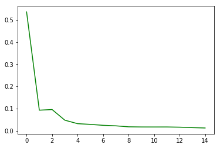

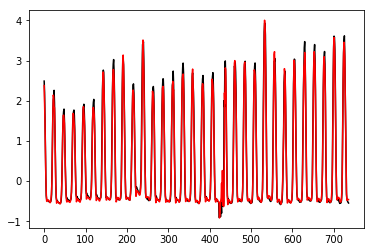

```python
plt.plot(losses,color='g')
plt.show()

plt.plot(y_test,color = 'k')
plt.plot(targets_predict,color = 'r')
plt.show()
```

```python
!ls -rtl /home/zzx/scenic_prediction/models2/01
```

```
总用量 200
drwxr-xr-x 2 zzx zzx   4096 7月  12 17:49 variables
-rw-rw-r-- 1 zzx zzx 199730 7月  12 17:49 saved_model.pb
```

### 3）模型部署

tensorflow serving 支持多种模型多种版本部署，可以实现AB测试，或者调用指定的模型版本

模型配置文件如下：

```python
!cat /home/zzx/scenic_prediction/tfserv.conf
```

```
model_config_list: {
  config: {
    name: "nanshanchi_1hours",
    base_path: "/home/zzx/scenic_prediction/nanshanchi_1hours",
    model_platform: "tensorflow"
  },
  config: {
     name: "nanshanchi_2hours",
     base_path: "/home/zzx/scenic_prediction/nanshanchi_2hours",
     model_platform: "tensorflow"
  },
  config: {
     name: "nanshanchi_3hours",
     base_path: "/home/zzx/scenic_prediction/nanshanchi_3hours",
     model_platform: "tensorflow"
  },
  config: {
    name: "daxiaodongtian_1hours",
    base_path: "/home/zzx/scenic_prediction/daxiaodongtian_1hours",
    model_platform: "tensorflow"
  },
  config: {
     name: "daxiaodongtian_2hours",
     base_path: "/home/zzx/scenic_prediction/daxiaodongtian_2hours",
     model_platform: "tensorflow"
  },
  config: {
     name: "daxiaodongtian_3hours",
     base_path: "/home/zzx/scenic_prediction/daxiaodongtian_3hours",
     model_platform: "tensorflow"
  },
  config: {
    name: "tianyahaijiao_1hours",
    base_path: "/home/zzx/scenic_prediction/tianyahaijiao_1hours",
    model_platform: "tensorflow"
  },
  config: {
     name: "tianyahaijiao_2hours",
     base_path: "/home/zzx/scenic_prediction/tianyahaijiao_2hours",
     model_platform: "tensorflow"
```

[output cut: 22 more lines]

```
    name: "wuzhizhoudao_1hours",
    base_path: "/home/zzx/scenic_prediction/wuzhizhoudao_1hours",
    model_platform: "tensorflow"
  },
  config: {
     name: "wuzhizhoudao_2hours",
     base_path: "/home/zzx/scenic_prediction/wuzhizhoudao_2hours",
     model_platform: "tensorflow"
  },
  config: {
     name: "wuzhizhoudao_3hours",
     base_path: "/home/zzx/scenic_prediction/wuzhizhoudao_3hours",
     model_platform: "tensorflow"
  },
}
```

执行下面的命令既可以把模型部署好了

tensorflow_model_server --port=8500 --model_config_file=./tfserv.conf

### 4）服务调用客户端

因为tensorflow serving 是通过protobuf来实现客户端和服务器之间的连接的，所以把protobuf文件编译成支持各种语言的客户端，请参考[tobegit3hub](https://github.com/tobegit3hub/tensorflow_template_application)，但是支持使用这样的客户端有点不方便。因为前端的人员还需要研究tensorflow serving的各种接口，代码耦合性很高，并且学习成本很大。本文通过官方支持的tensorflow-serving-api结合python版本的socketio库实现一个中转服务的RESTful接口，方便前端直接调用。本文写作的时候，查看官网发现serving已经官方支持[RESTful](https://tensorflow.google.cn/serving/api_rest)接口了，所以没必要自己实现，不过由于之前还没有，所以把已经写好的代码还是放到这里来吧。

socketio服务提供的接口，socketio支持各种版本的语言客户端，所以前端可以选择各种语言和本服务通讯。

```python
import numpy as np
import socketio
import eventlet
import eventlet.wsgi
from flask import Flask
from grpc.beta import implementations
import tensorflow as tf
from tensorflow_serving.apis import predict_pb2
from tensorflow_serving.apis import prediction_service_pb2
from tensorflow.python.framework import dtypes
import json

sio = socketio.Server()
app = Flask(__name__)


HOST="127.0.0.1"
PORT=8500


channel=implementations.insecure_channel(HOST,PORT)
stub=prediction_service_pb2.beta_create_PredictionService_stub(channel=channel)

@sio.on('scenic_prediction_2hour',namespace='/')
def nanshanchi_1hours(sid, data):
    if data:
        print(data)
        inputs=np.array(data.split(',')).astype(np.float64)
        request=predict_pb2.PredictRequest()
        request.model_spec.name='scenic_prediction_2hour'
        request.model_spec.signature_name='scenic_prediction_2hour'
        request.inputs['inputs'].CopyFrom(tf.contrib.util.make_tensor_proto(inputs,dtype=dtypes.float64,shape=[1, 20,1]))

        response=stub.Predict(request,10.0)
        print(response)
        results={}
        for key in response.outputs:
            tensor_proto=response.outputs[key]
            nd_array=tf.contrib.util.make_ndarray(tensor_proto)
            results[key]=str(nd_array[0][0])

        print(results)
        return json.dumps(results)

    else:
        print("no data")
        # NOTE: DON'T EDIT THIS.
        sio.emit('manual', data={}, skip_sid=True)


@sio.on('connect',namespace='/')
def connect(sid, environ):
    print("connect ", sid)

@sio.on('disconnect',namespace='/')
def disconnect(sid):
    print(sid)

# wrap Flask application with engineio's middleware
app = socketio.Middleware(sio, app)

# deploy as an eventlet WSGI server
eventlet.wsgi.server(eventlet.listen(('', 4567)), app)
```